# Analysis of Heart Failure based on Follow UP period

Ruchil Barya

06/06/2020

Including all libraries used in R

```r
library(WVPlots)
library(leaps)
library(dplyr)
library(ggplot2)
library(pwr)
library(readr)
library(reticulate)
library(aod)
library(broom)
library(infer)
library(pROC)
library(sigr)
library(WVPlots)
library(ranger)
library(boot)
```

# Objective

To analyze various contributing factors related to heart failure like age, red blood cells, high blood pressure, level of the creatinine phosphokinase in the blood, if the patient has diabetes or not, percentage of blood leaving the heart, number of platelets, sex, level of serum creatinine, serum sodium and if the patient is smoking. The goal of this research is to use regression models to predict the odds of death event during follow up period, time of follow up period based on the various factors analyzed.

# Load dataset

```r
heartFailData = read.csv("heartFailData.csv")
```

Data source: University of California Link: https://archive.ics.uci.edu/ml/datasets/Heart+failure+clinical+records  
File Path: https://archive.ics.uci.edu/ml/machine-learning-databases/00519/heart_failure_clinical_records_dataset.csv Size of data set: 299 observations Years – 2020 Total Variables – 13 Total Observations – 299 Dependent Variable – Death event(binary), time(num) Independent Variable considered – Age(num), anaemia(binary), high blood pressure(binary), creatinine phosphokinase(num), Diabetes(categorical), Ejection Fraction(num), Platelets(num), sex(binary), serum creatinine (num), serum sodium (num), smoking (binary)

# Data Cleaning - Outliers

```r
#leverage
modeltime = lm(time~.,data=heartFailData)
summary(modeltime)
```

```
##
## Call:
## lm(formula = time ~ ., data = heartFailData)
##
## Residuals:
##      Min       1Q   Median       3Q      Max
## -149.115  -49.439   -8.572   54.556  157.501
##
## Coefficients:
##                            Estimate Std. Error t value Pr(>|t|)
## (Intercept)               1.903e+02  1.245e+02   1.529   0.1274
## age                      -4.074e-01  3.370e-01  -1.209   0.2277
## anaemia                  -1.634e+01  7.841e+00  -2.084   0.0380 *
## creatinine_phosphokinase -1.093e-03  4.016e-03  -0.272   0.7856
## diabetes                  2.406e+00  7.850e+00   0.307   0.7594
## ejection_fraction        -6.398e-01  3.420e-01  -1.871   0.0624 .
## high_blood_pressure      -2.421e+01  8.000e+00  -3.027   0.0027 **
## platelets                -1.049e-05  3.931e-05  -0.267   0.7898
## serum_creatinine          1.502e+00  3.882e+00   0.387   0.6992
## serum_sodium              2.810e-01  8.977e-01   0.313   0.7545
## sex                      -5.829e+00  9.111e+00  -0.640   0.5229
## smoking                  -5.842e+00  9.105e+00  -0.642   0.5216
## DEATH_EVENT              -8.658e+01  9.196e+00  -9.415   <2e-16 ***
## ---
## Signif. codes:  0 '***' 0.001 '**' 0.01 '*' 0.05 '.' 0.1 ' ' 1
##
## Residual standard error: 64.89 on 286 degrees of freedom
## Multiple R-squared:  0.3292, Adjusted R-squared:  0.301
## F-statistic:  11.7 on 12 and 286 DF,  p-value: < 2.2e-16
```

```r
k=12
leverage = hatvalues(modeltime)
cutleverage = (2*k+2) / nrow(heartFailData)
badleverage = as.numeric(leverage > cutleverage)
table(badleverage)
```

```
## badleverage
##   0   1
## 284  15
```

```r
#cooks distance
cooks = cooks.distance(modeltime)
cutcooks = 4 / (nrow(heartFailData) - k - 1)
badcooks = as.numeric(cooks > cutcooks)
table(badcooks)
```

```
## badcooks
##   0   1
## 288  11
```

```r
#mahalanobis

datanew <- heartFailData[,c(1,3,5,7,8,9,12)]
mahal = mahalanobis(datanew,
                    colMeans(datanew),
                    cov(datanew))
cutmahal = qchisq(1-.001, ncol(datanew))
badmahal = as.numeric(mahal > cutmahal) ##note the direction of the >
table(badmahal)
```

```
## badmahal
##   0   1
## 287  12
```

```r
#total outlers

totalout = badmahal + badleverage + badcooks
table(totalout)
```

```
## totalout
##   0   1   2   3
## 278   9   7   5
```

```r
heartFailureData = subset(heartFailData, totalout < 3)
#total outliers = 5 (which satisfies all the three conditions)
```

# Data Screening

```r
heartFailureData$anaemia = as.factor(heartFailureData$anaemia)
heartFailureData$high_blood_pressure = as.factor(heartFailureData$high_blood_pressure)
heartFailureData$diabetes = as.factor(heartFailureData$diabetes)
heartFailureData$sex = as.factor(heartFailureData$sex)
heartFailureData$smoking = as.factor(heartFailureData$smoking)
heartFailureData$DEATH_EVENT = as.factor(heartFailureData$DEATH_EVENT)
summary(heartFailureData)
```

```
##       age        anaemia creatinine_phosphokinase diabetes ejection_fraction
##  Min.   :40.00   0:166   Min.   :  23.0           0:171    Min.   :14.00
##  1st Qu.:51.00   1:128   1st Qu.: 115.0           1:123    1st Qu.:30.00
##  Median :60.00           Median : 247.0                    Median :38.00
##  Mean   :61.05           Mean   : 537.8                    Mean   :37.94
##  3rd Qu.:70.00           3rd Qu.: 582.0                    3rd Qu.:45.00
##  Max.   :95.00           Max.   :7702.0                    Max.   :80.00
##  high_blood_pressure   platelets      serum_creatinine  serum_sodium   sex
##  0:190               Min.   : 25100   Min.   :0.500    Min.   :113.0   0:103
##  1:104               1st Qu.:212250   1st Qu.:0.900    1st Qu.:134.0   1:191
##                      Median :262000   Median :1.100    Median :137.0
##                      Mean   :260244   Mean   :1.373    Mean   :136.6
##                      3rd Qu.:302750   3rd Qu.:1.400    3rd Qu.:140.0
##                      Max.   :621000   Max.   :9.400    Max.   :148.0
##  smoking      time       DEATH_EVENT
##  0:200   Min.   :  4.0   0:200
##  1: 94   1st Qu.: 73.0   1: 94
##          Median :115.0
##          Mean   :130.2
##          3rd Qu.:204.0
##          Max.   :285.0
```

# Exploratory Data analysis

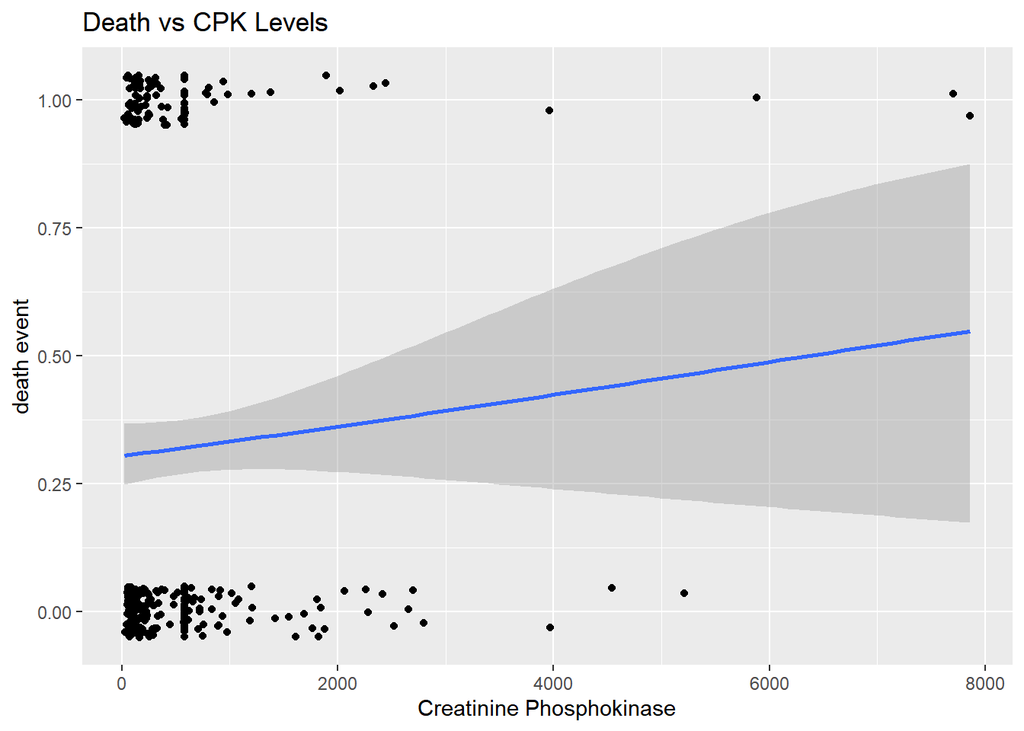

death odds seem to increase with cpk levels.

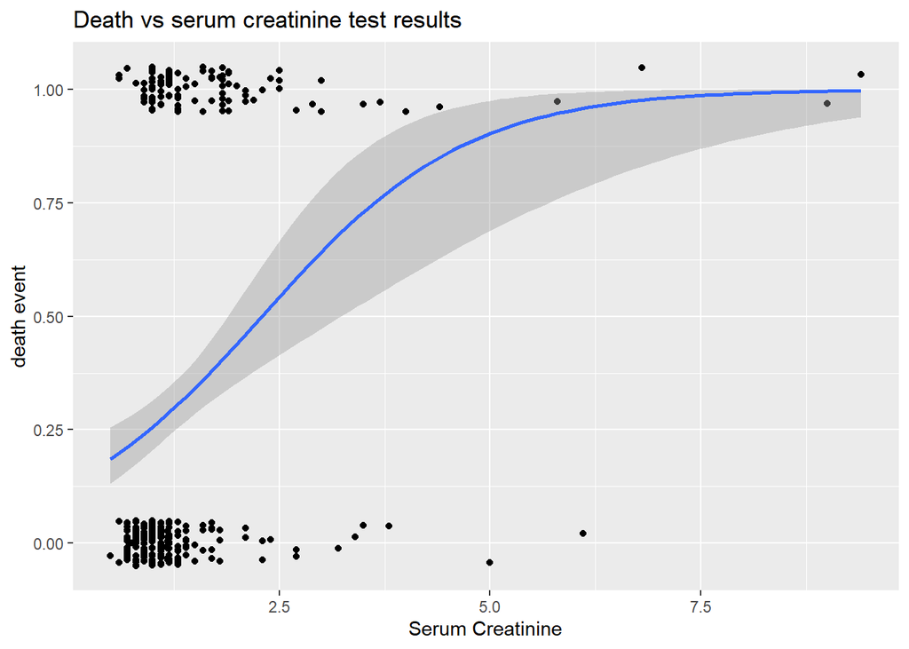

death event odds are less when serum creatinine levels are low

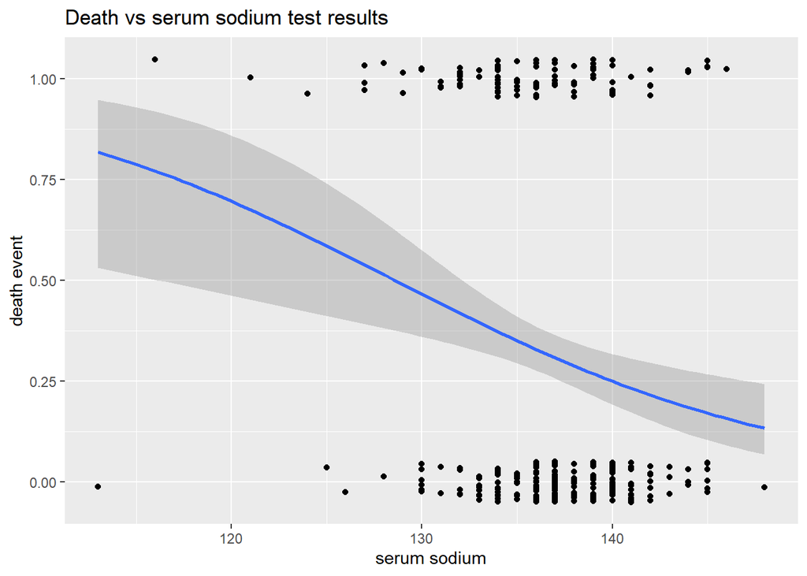

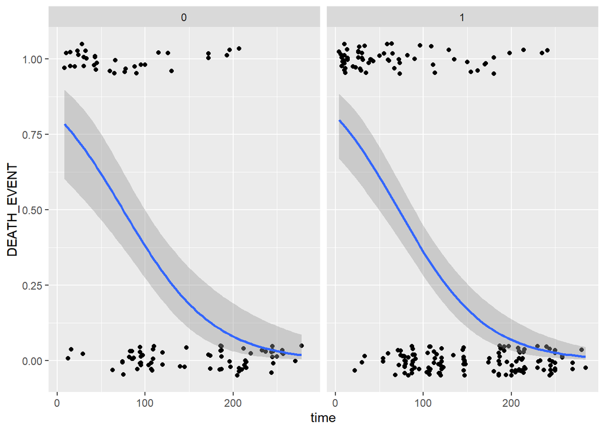

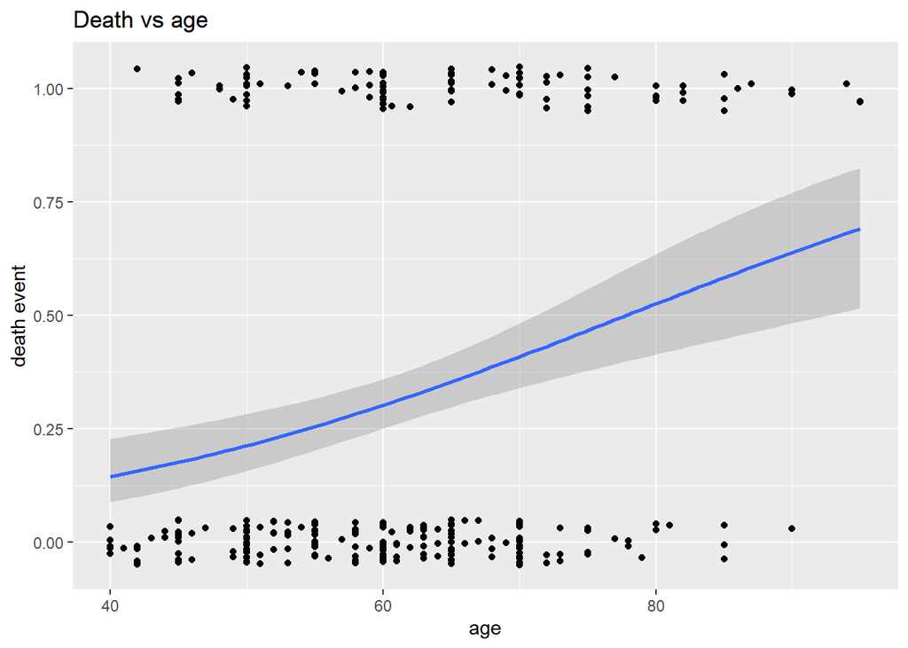

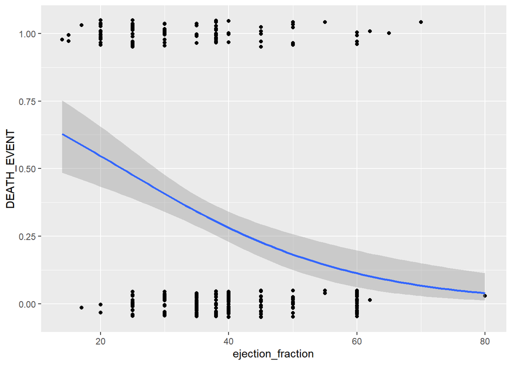

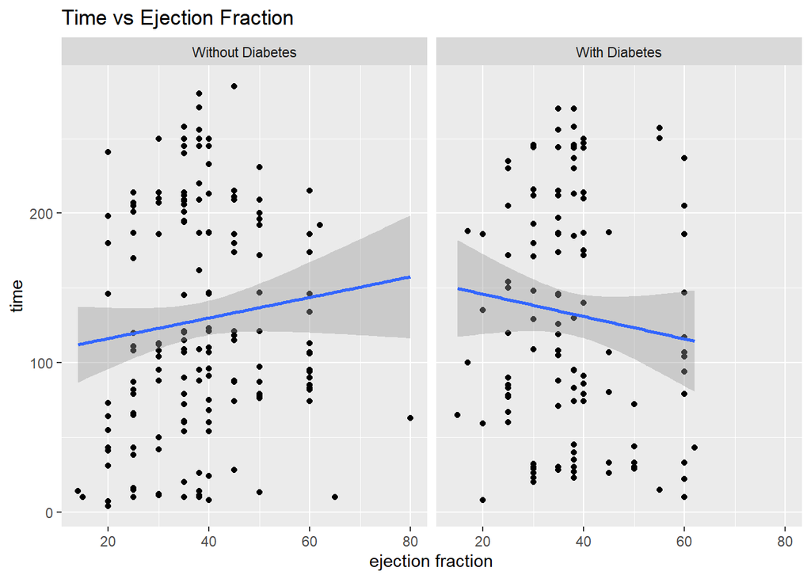

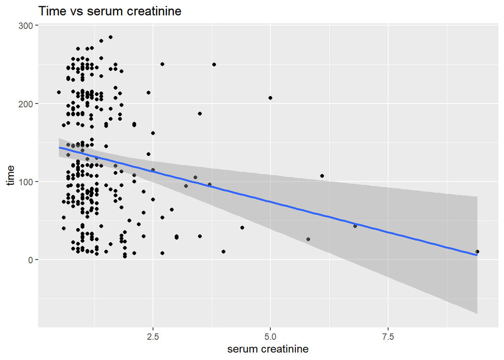

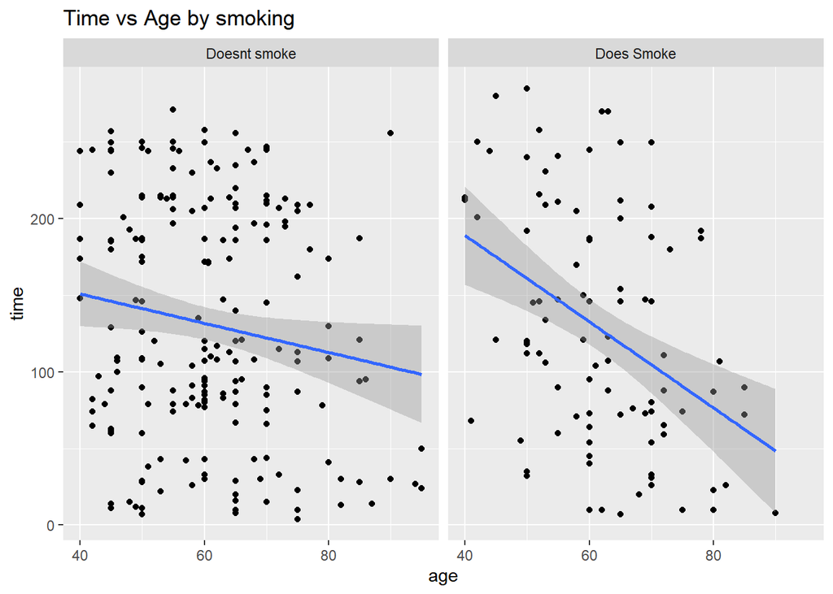

[figure not shown]

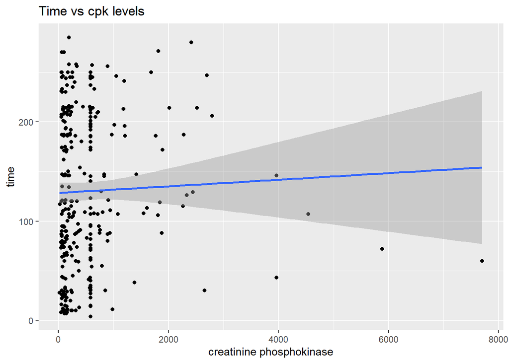

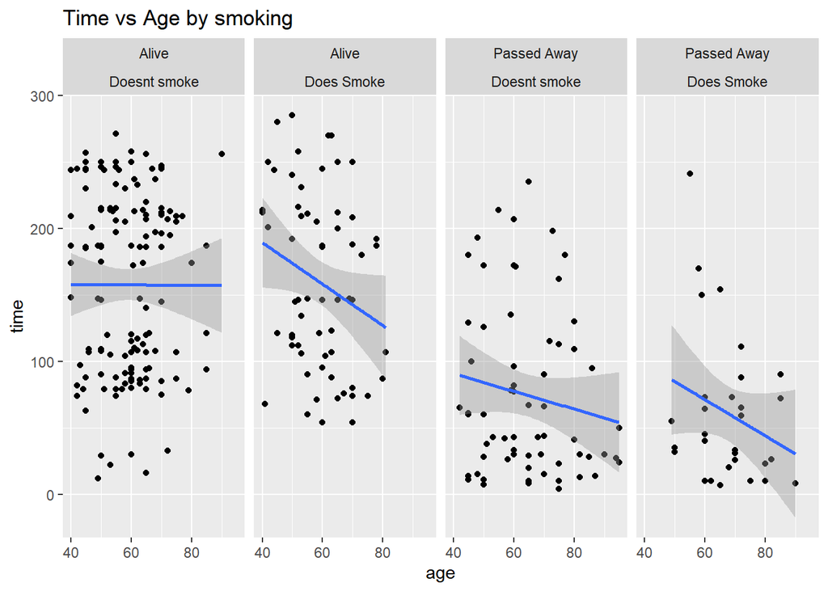

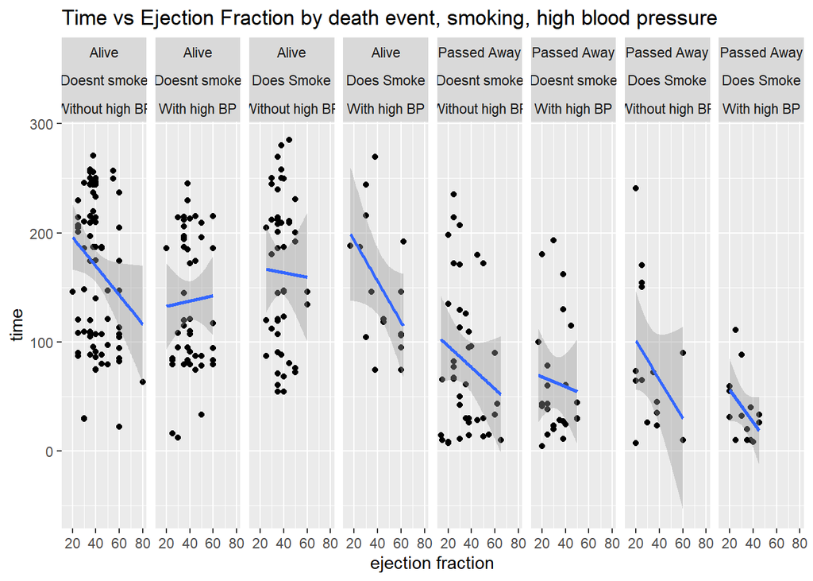

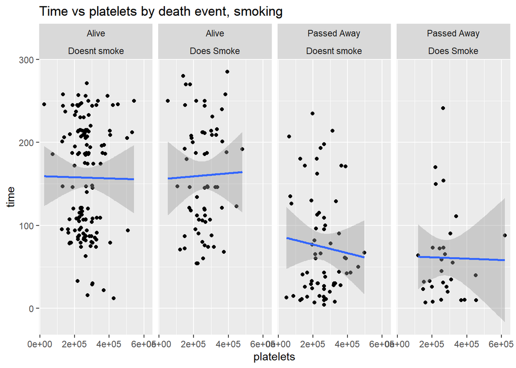

[6 more figures not shown]

There seems to be a difference in median time of the follow up period between people with high BP and people without high blood pressure. the difference of time is seen in when the patient was alive , patient passed away.

# Inferencial Analysis

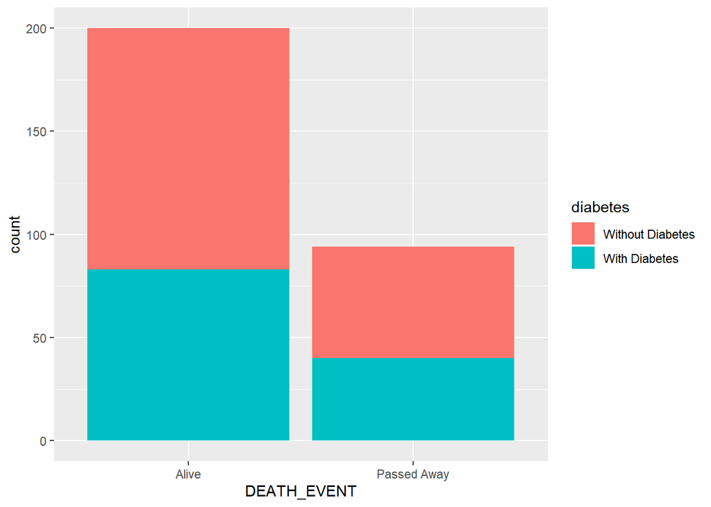

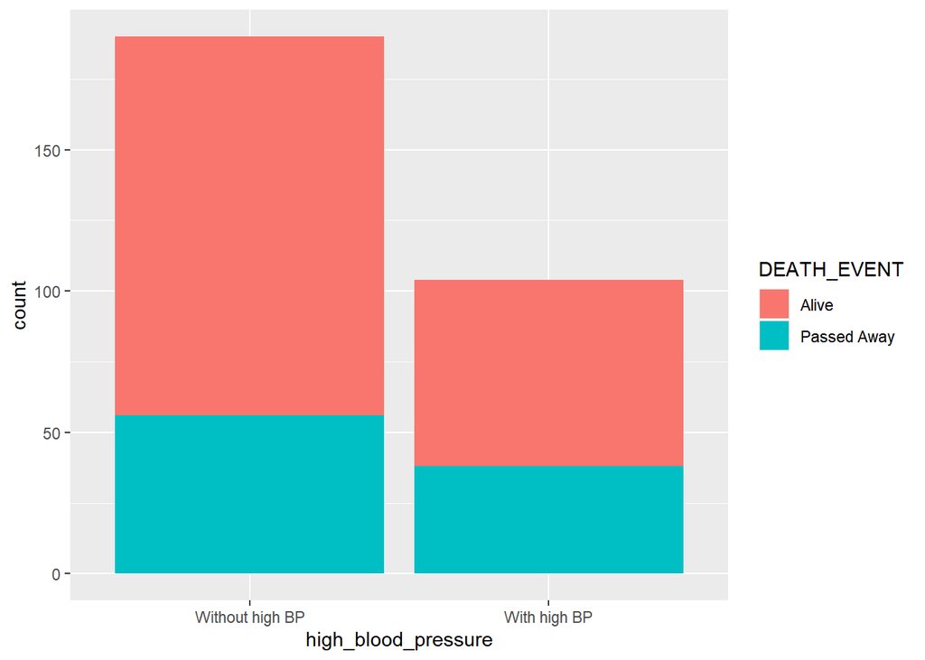

```
##       Alive Passed Away
##         200          94
```

```
## [1] 0.07064777
```

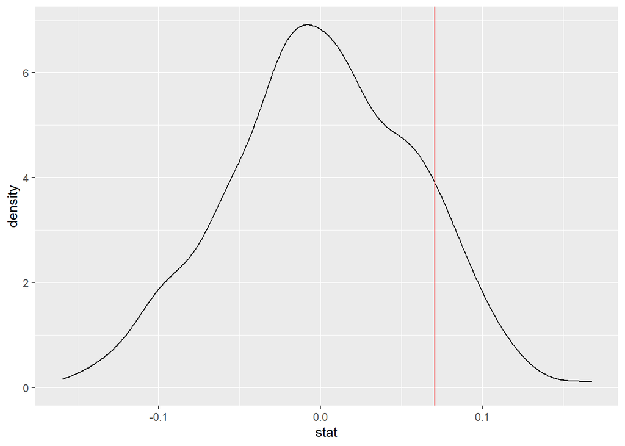

```
## # A tibble: 1 x 1
##    pval
##   <dbl>
## 1  1.77
```

The graph suggests there is no difference between two groups one with high blood pressure and one with not high blood pressure in the occurrence of death

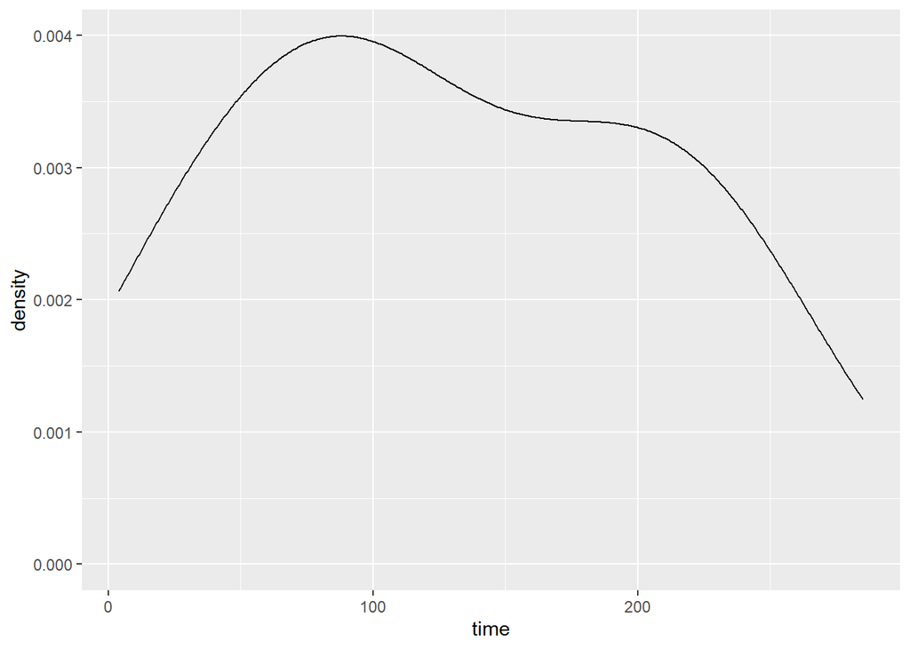

```r
heartFailDataInf %>%
  ggplot(aes(x=time)) +
  geom_density(adjust=2)
```

```r
aov(time ~ high_blood_pressure, heartFailDataInf) %>%
  tidy()
```

```
## # A tibble: 2 x 6
##   term                   df    sumsq meansq statistic   p.value
##   <chr>               <dbl>    <dbl>  <dbl>     <dbl>     <dbl>
## 1 high_blood_pressure     1   74443. 74443.      13.0  0.000371
## 2 Residuals             292 1675452.  5738.      NA   NA
```

```r
74442.97 / (74442.97 + 1675451.91)
```

```
## [1] 0.0425414
```

high blood pressure seem to be statistically significant with p < 0.05 and explains 4% of variance

By plotting observed statistic against null distribution, we learned that observed difference of 0.07 is not as greater then sort of difference we would see if there was no association between these two variables. This suggests there is no difference between two groups , one with high blood pressure and one with not high blood pressure in the occurence of death during the follow up period.

# Train and Test

```r
smp_size <- floor(0.75 * nrow(heartFailureData))

set.seed(299)
train_ind <- sample(seq_len(nrow(heartFailureData)), size = smp_size)
train <- heartFailureData[train_ind, ]
test <- heartFailureData[-train_ind, ]
```

# Binary Logistic regression

```r
m=glm(DEATH_EVENT ~ time + platelets + high_blood_pressure , data = train, family="binomial")
prob = predict(m, test, type="response")
mean(as.numeric(as.character(train$DEATH_EVENT)))
```

```
## [1] 0.3136364
```

```r
test$pred = ifelse(prob > 0.31, 1, 0)
mean(test$DEATH_EVENT == test$pred)
```

```
## [1] 0.6351351
```

```r
ROC = roc(test$DEATH_EVENT, prob)
```

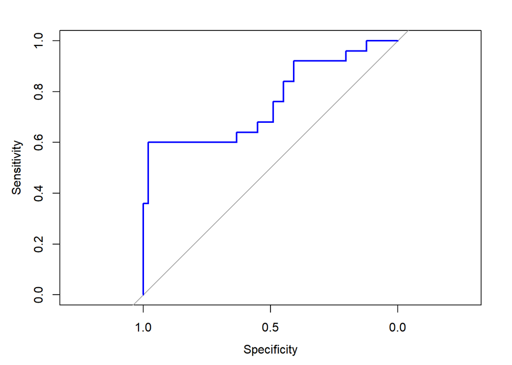

```r
plot(ROC, col="blue")
```

```r
auc(ROC)
```

```
## Area under the curve: 0.7633
```

#Stepwise Binary Logistic regression

```r
null_model = glm(DEATH_EVENT ~ 1 , data = train, family="binomial")

full_model = glm(DEATH_EVENT ~., data = train, family="binomial")

step_model = step(null_model, scope=list(lower=null_model, upper = full_model), directoin="forward")
```

```
## Start:  AIC=275.67
## DEATH_EVENT ~ 1
##
##                            Df Deviance    AIC
## + time                      1   186.32 190.32
## + ejection_fraction         1   254.33 258.33
## + serum_creatinine          1   256.48 260.48
## + age                       1   256.64 260.64
## + serum_sodium              1   265.21 269.21
## <none>                          273.67 275.67
## + high_blood_pressure       1   272.55 276.55
## + anaemia                   1   272.82 276.82
## + diabetes                  1   273.12 277.12
## + smoking                   1   273.38 277.38
## + creatinine_phosphokinase  1   273.40 277.40
## + sex                       1   273.67 277.67
## + platelets                 1   273.67 277.67
##
## Step:  AIC=190.32
## DEATH_EVENT ~ time
##
##                            Df Deviance    AIC
## + ejection_fraction         1   166.62 172.62
## + age                       1   176.40 182.40
## + serum_creatinine          1   177.50 183.50
## + serum_sodium              1   178.07 184.07
## <none>                          186.32 190.32
## + diabetes                  1   185.32 191.32
## + creatinine_phosphokinase  1   185.61 191.61
## + platelets                 1   185.90 191.90
## + high_blood_pressure       1   186.00 192.00
## + smoking                   1   186.27 192.27
## + anaemia                   1   186.30 192.30
## + sex                       1   186.32 192.32
## - time                      1   273.67 275.67
##
## Step:  AIC=172.62
## DEATH_EVENT ~ time + ejection_fraction
##
##                            Df Deviance    AIC
```

[output cut: 72 more lines]

```
##
##                            Df Deviance    AIC
## <none>                          142.86 156.86
## - diabetes                  1   145.35 157.35
## - serum_sodium              1   145.52 157.52
## + sex                       1   142.02 158.02
## + smoking                   1   142.26 158.26
## + creatinine_phosphokinase  1   142.49 158.49
## + platelets                 1   142.59 158.59
## + high_blood_pressure       1   142.80 158.80
## + anaemia                   1   142.85 158.85
## - serum_creatinine          1   147.39 159.39
## - age                       1   154.35 166.35
## - ejection_fraction         1   163.84 175.84
## - time                      1   219.09 231.09
```

```r
step_prob = predict(step_model, test, type= "response")
ROC3 = roc(test$DEATH_EVENT, step_prob)
```

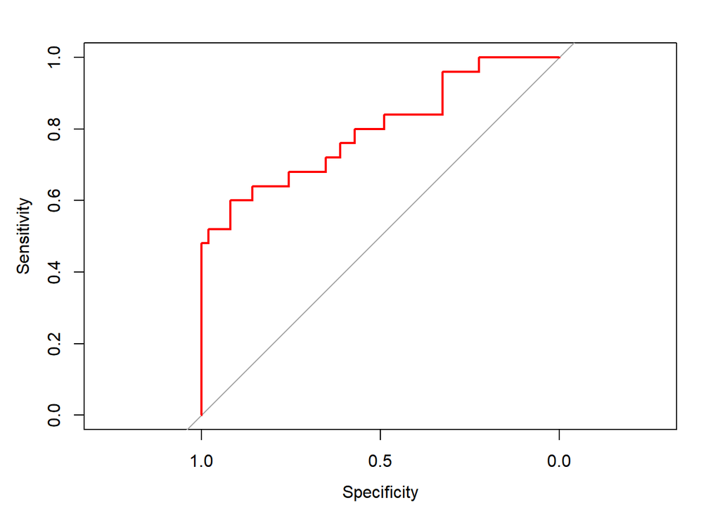

```r
plot(ROC3, col="red")
```

```r
auc(ROC3)
```

```
## Area under the curve: 0.7984
```

Evaluation of AUC:

From the graph we can see that area under the curve is greater area – Our curve is not close to the 45-degree diagonal of the ROC space, which suggest the model has higher accuracy. Which suggest we have good rate for positive test where people are correctly identified with the heart failure at the time when they visit the hospital.

# Assumption for logistic regression

## Additivity

```r
correl = cor(heartFailData[,c(1,3,5,7,8,9,12)])
symnum(correl)
```

```
##                          a c e p srm_c srm_s t
## age                      1
## creatinine_phosphokinase   1
## ejection_fraction            1
## platelets                      1
## serum_creatinine                 1
## serum_sodium                           1
## time                                         1
## attr(,"legend")
## [1] 0 ' ' 0.3 '.' 0.6 ',' 0.8 '+' 0.9 '*' 0.95 'B' 1
```

```r
#it does met the assumption of additivity as correlation values are less than 0.7 and there is no multicollinearity

#Additivity - we already meet the assumption of additivity (verified for logistic regression)

#new model after removing outliers(to check assumptions)
modeltime = lm(time~.,heartFailureData)
summary(modeltime)
```

```
##
## Call:
## lm(formula = time ~ ., data = heartFailureData)
##
## Residuals:
##      Min       1Q   Median       3Q      Max
## -155.780  -46.734   -9.286   52.874  154.889
##
## Coefficients:
##                            Estimate Std. Error t value Pr(>|t|)
## (Intercept)               2.029e+02  1.229e+02   1.651 0.099903 .
## age                      -3.158e-01  3.355e-01  -0.941 0.347353
## anaemia1                 -1.665e+01  7.706e+00  -2.160 0.031588 *
## creatinine_phosphokinase  2.490e-03  4.585e-03   0.543 0.587492
## diabetes1                 2.281e+00  7.743e+00   0.295 0.768543
## ejection_fraction        -8.627e-01  3.426e-01  -2.518 0.012362 *
## high_blood_pressure1     -2.643e+01  7.907e+00  -3.343 0.000942 ***
## platelets                -1.806e-06  4.314e-05  -0.042 0.966630
## serum_creatinine         -3.389e+00  4.228e+00  -0.801 0.423594
## serum_sodium              2.225e-01  8.850e-01   0.251 0.801686
## sex1                     -3.327e+00  8.977e+00  -0.371 0.711173
## smoking1                 -4.864e+00  8.982e+00  -0.542 0.588554
## DEATH_EVENT1             -8.725e+01  9.054e+00  -9.636  < 2e-16 ***
## ---
## Signif. codes:  0 '***' 0.001 '**' 0.01 '*' 0.05 '.' 0.1 ' ' 1
##
## Residual standard error: 63.62 on 281 degrees of freedom
## Multiple R-squared:   0.35,  Adjusted R-squared:  0.3222
## F-statistic: 12.61 on 12 and 281 DF,  p-value: < 2.2e-16
```

## Linearity

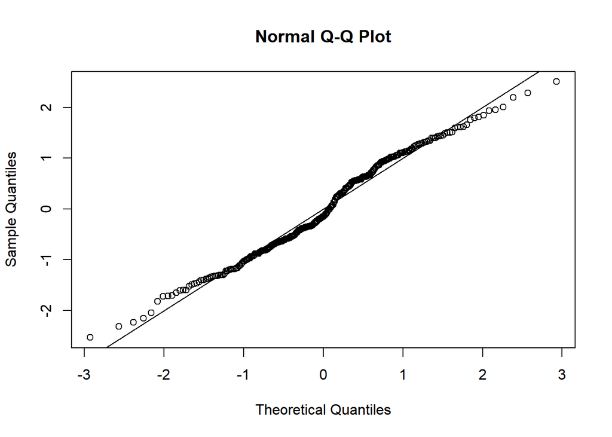

```r
#linearity
standardized = rstudent(modeltime)
fitted = scale(modeltime$fitted.values)
qqnorm(standardized)
abline(0,1)
```

Yes , it met the assumption of linearity as the dots are close to line

## Normality

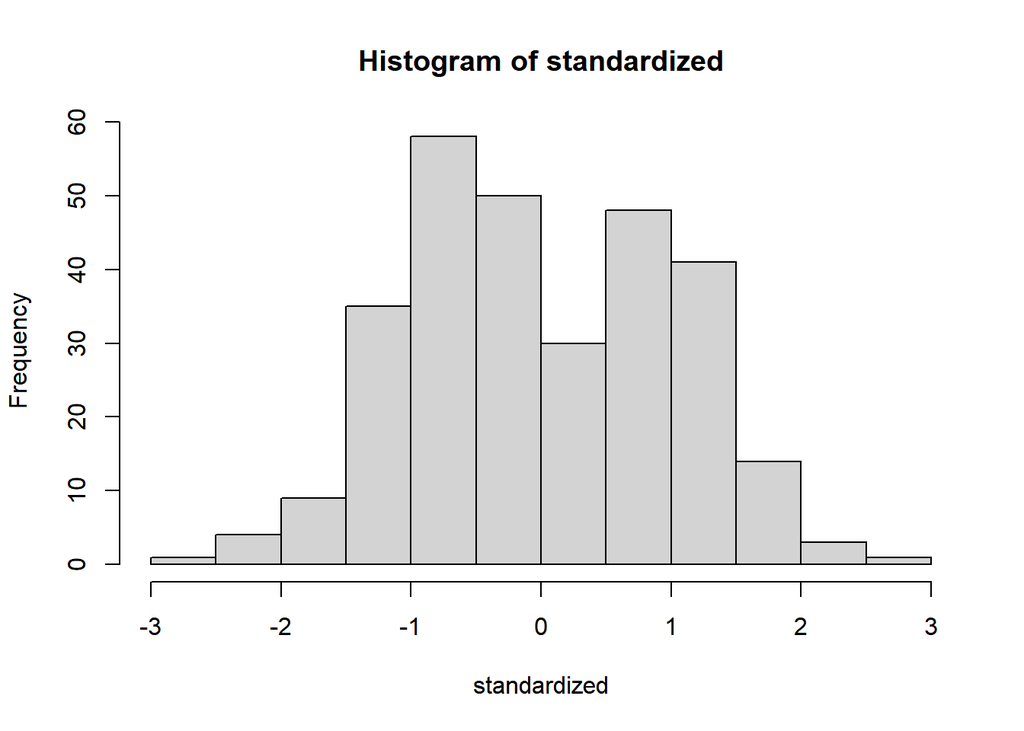

```r
hist(standardized)
```

```r
library(moments)
skewness(datanew)
```

```
##                      age creatinine_phosphokinase        ejection_fraction
##                0.4209366                4.4406886                0.5525927
##                platelets         serum_creatinine             serum_sodium
##                1.4549745                4.4336102               -1.0428705
##                     time
##                0.1271606
```

```r
kurtosis(datanew)
```

```
##                      age creatinine_phosphokinase        ejection_fraction
##                 2.798207                27.710458                 3.020720
##                platelets         serum_creatinine             serum_sodium
##                 9.085906                28.378346                 7.031142
##                     time
##                 1.788126
```

```r
shapiro.test(modeltime$residuals)
```

```
##
##  Shapiro-Wilk normality test
##
## data:  modeltime$residuals
## W = 0.98331, p-value = 0.00168
```

creatinine_phosphokinase and serum_creatinine has very high skew value does not met the assumption of normality as the p value is less 0.05

#Heterocadasticity

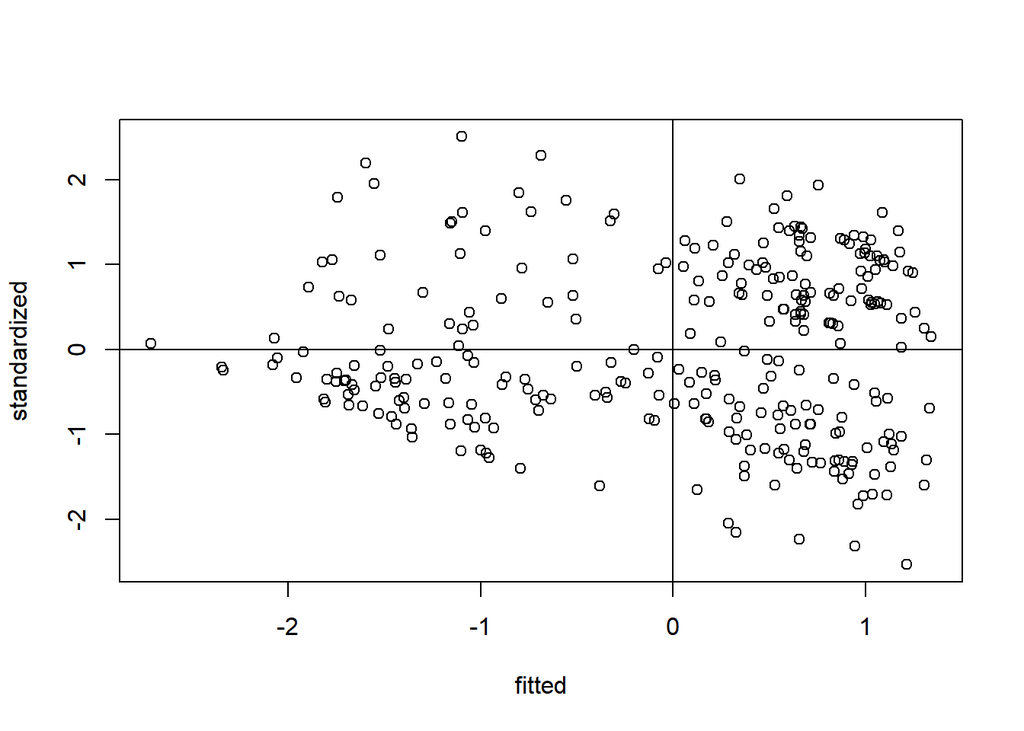

```r
plot(fitted, standardized)
abline(0,0)
abline(v = 0)
```

```r
library(car)
vif(modeltime)
```

```
##                      age                  anaemia creatinine_phosphokinase
##                 1.145810                 1.060374                 1.055992
##                 diabetes        ejection_fraction      high_blood_pressure
##                 1.059589                 1.164590                 1.038030
##                platelets         serum_creatinine             serum_sodium
##                 1.039234                 1.149905                 1.114320
##                      sex                  smoking              DEATH_EVENT
##                 1.332182                 1.274569                 1.294973
```

It meet the assumption of Homogeneity and Homoscedasticity as the variance is spread evenly across y axis from -2 to +2,also VIF is less than 5

# Linear regression

```r
myTimeModel1 = lm(time~ejection_fraction+high_blood_pressure+DEATH_EVENT, data = train)
wrapFTest(myTimeModel1)
```

```
## [1] "F Test summary: (R2=0.3689, F(3,216)=42.08, p<1e-05)."
```

```r
test$timePred1 = predict(myTimeModel1, newdata = test)
test$residuals = test$time - test$timePred1
summary(test$time)
```

```
##    Min. 1st Qu.  Median    Mean 3rd Qu.    Max.
##    4.00   85.25  116.00  132.70  204.00  258.00
```

```r
summary(test$timePred1)
```

```
##    Min. 1st Qu.  Median    Mean 3rd Qu.    Max.
##   33.37   74.13  148.21  127.35  169.12  181.88
```

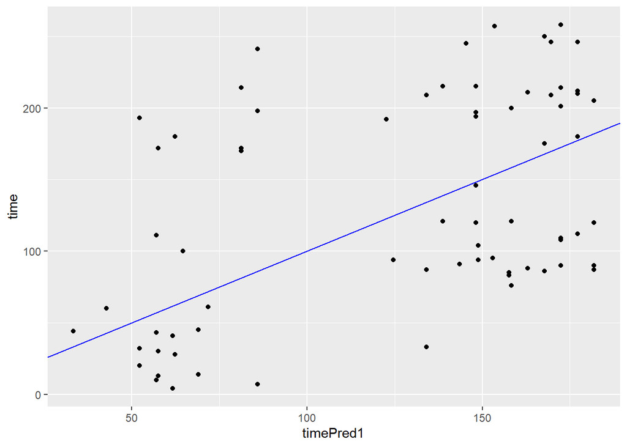

```r
test %>%
  ggplot(aes(x=timePred1, y=time)) +
  geom_point() +
  geom_abline(color = "blue")
```

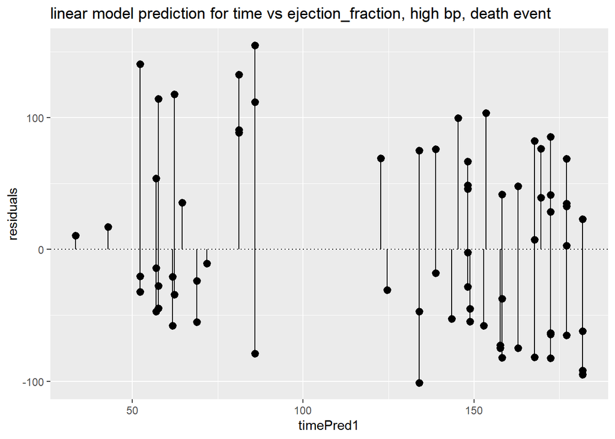

```r
test %>%
  ggplot(aes(x=timePred1, y=residuals)) +
  geom_pointrange(aes(ymin=0, ymax=residuals)) +
  geom_hline(yintercept = 0, linetype = 3) +
  ggtitle("linear model prediction for time vs ejection_fraction, high bp, death event")
```

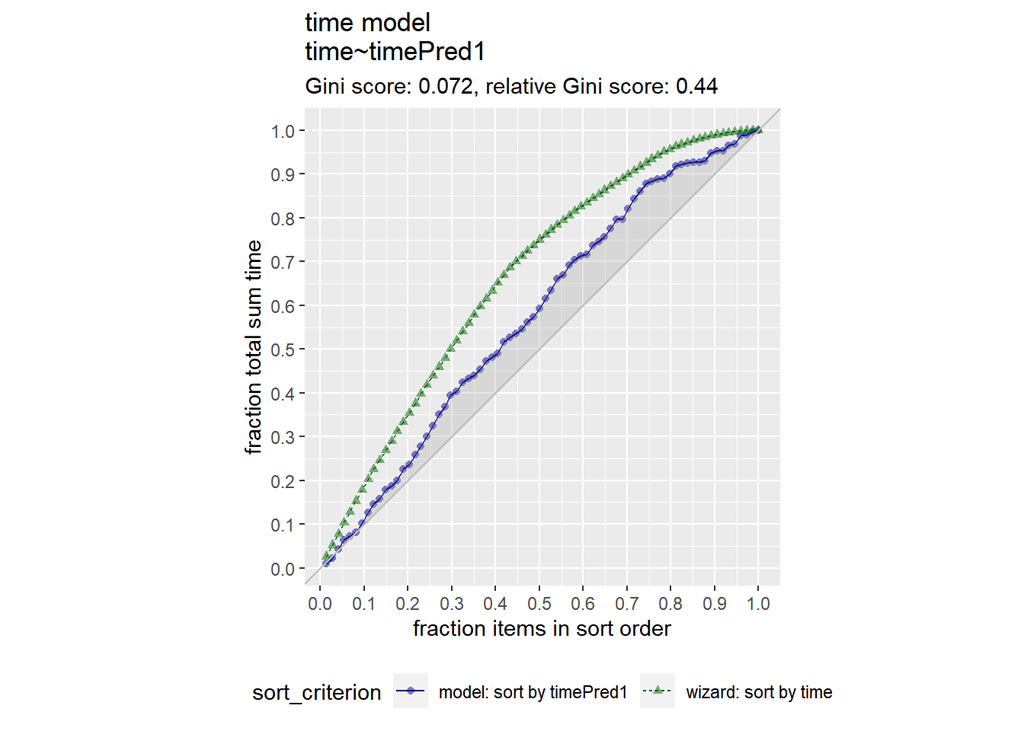

```r
GainCurvePlot(test, "timePred1", "time", "time model")
```

```r
rmse = sqrt(mean(test$residuals ^ 2))
print("rmse")
```

```
## [1] "rmse"
```

```r
rmse
```

```
## [1] 67.71416
```

```r
print("standard deviation")
```

```
## [1] "standard deviation"
```

```r
sd(test$time)
```

```
## [1] 76.04968
```

```r
print("r square")
```

```
## [1] "r square"
```

```r
glance(myTimeModel1)$r.squared
```

```
## [1] 0.3688733
```

diagnol line shows the if the time is random green is the curve where perfect model would trace out blue is the curve our model traces out

rmse of 67.71 is better than standard deviation of 76.04

# Random Forest

```r
myTimeModel2 = ranger(time~ejection_fraction+high_blood_pressure+DEATH_EVENT, train, num.trees = 500, respect.unordered.factors = "order", seed = 299)

test$timePred2 = predict(myTimeModel2, test)$predictions
test$residuals2 = test$time - test$timePred2
summary(test$time)
```

```
##    Min. 1st Qu.  Median    Mean 3rd Qu.    Max.
##    4.00   85.25  116.00  132.70  204.00  258.00
```

```r
summary(test$timePred2)
```

```
##    Min. 1st Qu.  Median    Mean 3rd Qu.    Max.
##    64.5    86.2   140.0   126.5   158.6   169.4
```

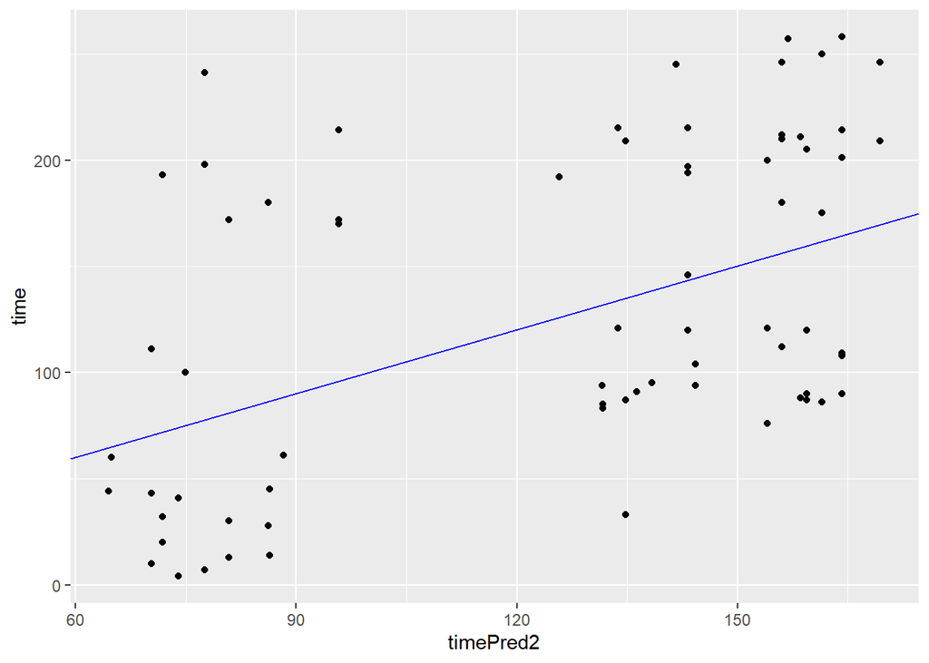

```r
test %>%
  ggplot(aes(x=timePred2, y=time)) +
  geom_point() +
  geom_abline(color = "blue")
```

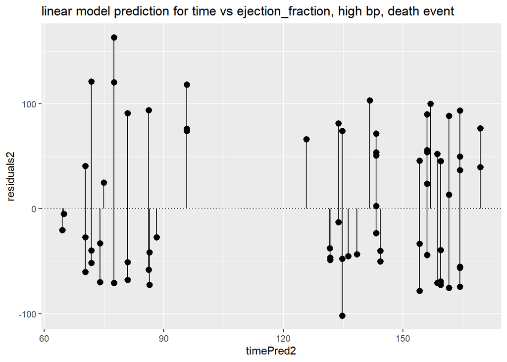

```r
test %>%
  ggplot(aes(x=timePred2, y=residuals2)) +
  geom_pointrange(aes(ymin=0, ymax=residuals2)) +
  geom_hline(yintercept = 0, linetype = 3) +
  ggtitle("linear model prediction for time vs ejection_fraction, high bp, death event")
```

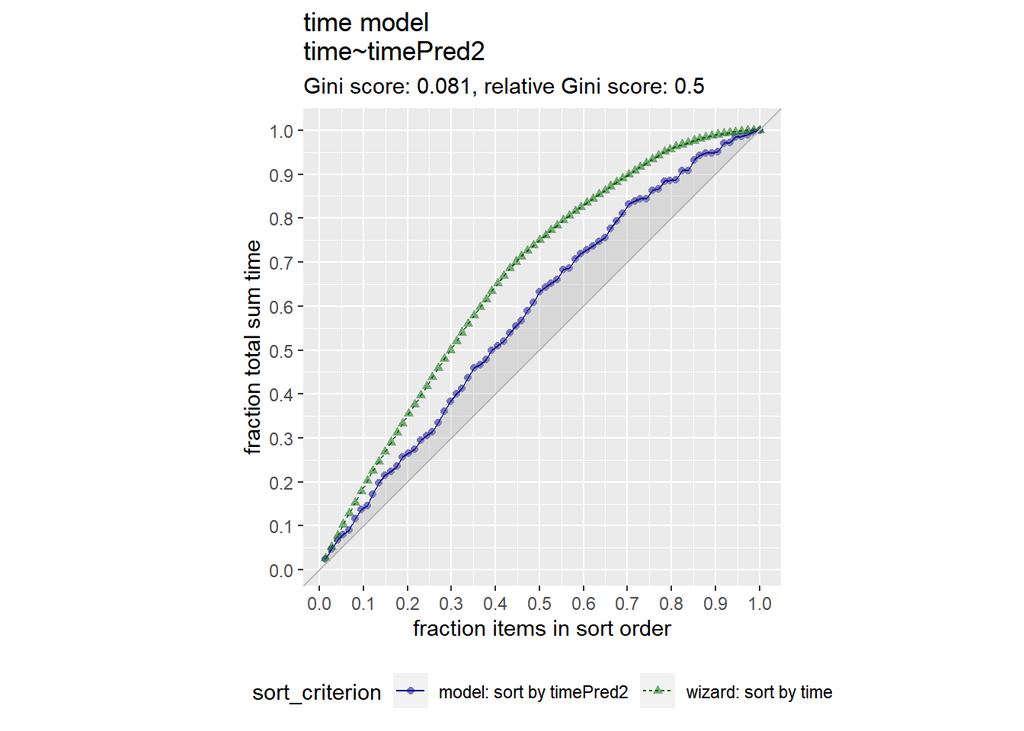

```r
GainCurvePlot(test, "timePred2", "time", "time model")
```

```r
print("rmse")
```

```
## [1] "rmse"
```

```r
rmse = sqrt(mean(test$residuals2 ^ 2))
rmse
```

```
## [1] 66.12833
```

```r
print("standard deviation")
```

```
## [1] "standard deviation"
```

```r
sd(test$time)
```

```
## [1] 76.04968
```

```r
print("r square")
```

```
## [1] "r square"
```

```r
glance(myTimeModel1)$r.squared
```

```
## [1] 0.3688733
```

rmse improved from 67.71 to 66.12 utilizing random forest algorithm for test data.

```r
anova(myTimeModel1, myTimeModel2)
```

```
## Analysis of Variance Table
##
## Response: time
##                      Df Sum Sq Mean Sq  F value    Pr(>F)
## ejection_fraction     1    765     765   0.1972 0.6574383
## high_blood_pressure   1  50255   50255  12.9601 0.0003947 ***
## DEATH_EVENT           1 438512  438512 113.0877 < 2.2e-16 ***
## Residuals           216 837568    3878
## ---
## Signif. codes:  0 '***' 0.001 '**' 0.01 '*' 0.05 '.' 0.1 ' ' 1
```

To evaluate the linear regression model We are using train and test data – with Sample size of 0.75 Train data is for running the models and test data is for the predictions